# Most Harmful Storm Events Across the States for People and Economy

Sertinell

12 November 2015

# Sipnosys

In this study we explore the impact of storm events in the life of the United States of America inhabitants. We explore both, the impact in health and in economy. To identify the most harmful events for health we compare the total number of fatalities and injuries caused by each kind of event. To identify the most harmful eventsin terms of economic impact we compare tha amount of property damage and crop damage. We found that only four type events account for almost the 80% of the fatalities and more than 85% of the injuries. Simlarly, the five most harmful type of events account for more than 97% of the property damage and more than 84% of the crop damage.

# Data Processing

```r
require(data.table)
require(dplyr)
```

```r
require(ggplot2)
require(scales)
```

### Load data

Download the file, read it using fread through a bzcat to uncompress it into a *data.frame*.

```r
filename <- "data/storms.csv.bz2"
download.file("https://d396qusza40orc.cloudfront.net/repdata%2Fdata%2FStormData.csv.bz2", destfile = filename)
stormdata <-fread(sprintf("bzcat %s | tr -d '\\000'", filename))
```

```
##
Read 0.0% of 967216 rows
Read 22.7% of 967216 rows
Read 38.3% of 967216 rows
Read 50.7% of 967216 rows
Read 56.9% of 967216 rows
Read 71.3% of 967216 rows
Read 78.6% of 967216 rows
Read 84.8% of 967216 rows
Read 902297 rows and 37 (of 37) columns from 0.523 GB file in 00:00:12
```

### Clean up data

Since all the questions refer to data across the states, I have dropped out all the columns related to location.

```r
notwanted <- c(1,4:7,9:11,14:20, 30:37)
stormdata <- select(stormdata, -notwanted)
```

Change the columns names to lower case and remove “_”

```r
names(stormdata) <- tolower(names(stormdata))
names(stormdata) <- sub("_", "", names(stormdata))
names(stormdata)
```

```
##  [1] "bgndate"    "bgntime"    "evtype"     "enddate"    "endtime"
##  [6] "f"          "mag"        "fatalities" "injuries"   "propdmg"
## [11] "propdmgexp" "cropdmg"    "cropdmgexp" "wfo"
```

### Calculate the actual damage

It seems that the *propdmgexp* and the *cropdmgexp* are the exponents of the *propdmg* and *cropdmg* respectively. We are using those colums to generate an extra column with the absolute value.

```r
table(stormdata$cropdmgexp)
```

```
##
##             ?      0      2      B      k      K      m      M
## 618413      7     19      1      9     21 281832      1   1994
```

```r
table(stormdata$propdmgexp)
```

```
##
##             -      ?      +      0      1      2      3      4      5
## 465934      1      8      5    216     25     13      4      4     28
##      6      7      8      B      h      H      K      m      M
##      4      5      1     40      1      6 424665      7  11330
```

Numbers are taken as exponent of scientific notation (10*x) and letters are taken as follows:

- B: Billions 10^12
- k|K : Kilo 10^3
- M|m : Millions 10^6
- H|h : Hecto 10^2

Other values and blanks are assigned 0.

```r
values <- data.frame(
  letters = c("B", "k", "K", "m", "M", "H", "h"),
  value =   c(  12,   3,   3,  6,   6 ,   2,  2)
  );
for(letter in values$letters){
  stormdata$cropdmgexp[stormdata$cropdmgexp == letter] <-
    values$value[values$letters == letter]
  stormdata$propdmgexp[stormdata$propdmgexp == letter] <-
    values$value[values$letters == letter]
}

stormdata$cropdmgexp <- as.integer(stormdata$cropdmgexp)
stormdata$propdmgexp <- as.integer(stormdata$propdmgexp)
stormdata$cropdmgexp[is.na(stormdata$cropdmgexp)] <- 0
stormdata$propdmgexp[is.na(stormdata$propdmgexp)] <- 0

stormdata <- mutate(stormdata, propertydamage = propdmg * 10^propdmgexp, cropdamage = cropdmg * 10^cropdmgexp )
```

Drop old columns

```r
stormdata <- select(stormdata, -c(cropdmg, propdmg, cropdmgexp, propdmgexp))
```

### Clean up the *evtype* column

Extract the evtype column and inspect it to decide how to clean up this messy column. Get all the unique values and short it alphabetycally.

```r
evtype <- unique(stormdata$evtype)
evtype <- evtype[order(evtype)]
evtype <- tolower(evtype)
evtype
```

```
##   [1] "?"                              "abnormally dry"
##   [3] "abnormally wet"                 "abnormal warmth"
##   [5] "accumulated snowfall"           "agricultural freeze"
##   [7] "apache county"                  "astronomical high tide"
##   [9] "astronomical low tide"          "avalance"
##  [11] "avalanche"                      "beach erosin"
##  [13] "beach erosion"                  "beach erosion"
##  [15] "beach erosion/coastal flood"    "beach flood"
##  [17] "below normal precipitation"     "bitter wind chill"
##  [19] "bitter wind chill temperatures" "black ice"
##  [21] "black ice"                      "blizzard"
##  [23] "blizzard and extreme wind chil" "blizzard and heavy snow"
##  [25] "blizzard/freezing rain"         "blizzard/heavy snow"
##  [27] "blizzard/high wind"             "blizzard summary"
##  [29] "blizzard weather"               "blizzard/winter storm"
```

[output cut: 478 more lines]

I have decided to keep only the most common *words* and consider every evtype that contains a certain word as an event of this word type.

Split all the evtype values by words to find the most common words longer than 2 characters:

```r
words <- unlist(strsplit(evtype,'[^a-zA-Z]', perl = TRUE))
words <- unique(words)
words <- words[order(words)]
words <- words[nchar(words) > 2]
```

Count the times every type appears:

```r
stormdata$evtype <- tolower(stormdata$evtype)
wordtable <- lapply(words, FUN=function(x){
              sum(grepl(x, stormdata$evtype))
             })
wordtable <- data.frame(word = words, count = unlist(wordtable))
wordtable <- wordtable[order(-wordtable$count),]
head(wordtable, 20)
```

```
##             word  count
## 329          win 384628
## 330         wind 364901
## 125         hail 290401
## 295         tstm 227236
## 256        storm 124624
## 275 thunderstorm 109572
## 99         flood  82731
## 287      tornado  60700
## 16           ash  55704
## 94         flash  55677
## 132        heavy  27984
## 133         high  23068
## 143         inds  22989
## 332        winds  22988
## 336       winter  19604
## 243          sno  17706
## 244         snow  17705
## 160        light  15987
## 162    lightning  15776
## 170       marine  12615
```

We can see that words like *heavy*, *high* and others appear on the top of our list. Drop them because they are too vague.

```r
dropwords <- c("heavy", "high", "strong", "extreme", "record", "light")
wordtable <- wordtable[-which(wordtable$word %in% dropwords),]
```

Now we need to run a loop and assign the *word* value to a new column called *cleanevent* to every event that matches each of the *words*. Every event is assigned a *cleanevent* value only once.

```r
stormdata$cleanevent <- as.character("")
stormdata$cleanevent <- NA
for(event in wordtable$word)
  {
    stormdata$cleanevent[is.na(stormdata$cleanevent) &
                          grepl(event, stormdata$evtype) ] <- event
  }
```

We got *only* 85 levels and there is only 9 NA event. The NA values don’t seem to be important.

```r
length(table(stormdata$cleanevent))
```

```
## [1] 85
```

```r
sum(is.na(stormdata$cleanevent))
```

```
## [1] 9
```

```r
stormdata[is.na(stormdata$cleanevent),]
```

```
##               bgndate     bgntime      evtype           enddate
## 1:  6/11/1995 0:00:00        0000 record high
## 2:  6/11/1995 0:00:00        0000 record high
## 3:  6/12/1995 0:00:00        0000 record high
## 4:  6/13/1995 0:00:00        0000 record high
## 5:  6/11/1995 0:00:00        0000 record high
## 6: 11/16/1994 0:00:00        0800        high
## 7:   2/9/1994 0:00:00        0600           ?  2/9/1994 0:00:00
## 8:  2/22/1997 0:00:00 12:28:00 PM record high 2/22/1997 0:00:00
## 9:  2/27/1997 0:00:00 05:24:00 PM record high 2/27/1997 0:00:00
##        endtime f mag fatalities injuries wfo
## 1:                 0          0        0
## 2:                 0          0        0
## 3:                 0          0        0
## 4:                 0          0        0
```

[output cut: 25 more lines]

## Which types of events are most harmful with respect to population health?

To show the impact of events in population health we need to consider the columns *injuries* and *fatalities*. Short the data according to those columns. It seems the worst recorded events were tornadoes and heatwaves.

```r
stormdata <- arrange(stormdata, desc(fatalities),
                     desc(injuries))
head(stormdata)
```

```
##              bgndate     bgntime         evtype           enddate
## 1: 7/12/1995 0:00:00        1100           heat 7/16/1995 0:00:00
## 2: 5/22/2011 0:00:00 04:40:00 PM        tornado 5/22/2011 0:00:00
## 3:  6/8/1953 0:00:00        1930        tornado
## 4: 5/11/1953 0:00:00        1610        tornado
## 5: 7/28/1999 0:00:00 11:00:00 AM excessive heat 7/31/1999 0:00:00
## 6:  6/9/1953 0:00:00        1425        tornado
##        endtime f mag fatalities injuries wfo
## 1:     1700CST     0        583        0
## 2: 05:00:00 PM 5   0        158     1150 SGF
## 3:             5   0        116      785
## 4:             5   0        114      597
## 5: 07:00:00 AM     0         99        0 LOT
## 6:             4   0         90     1228
##                                                                                                                                                                                                                                                                                                          …
## 1: An intense heat wave affected northern Illinois from Wednesday July 12 through Sunday July 16. The heat wave tied or broke several temperature records at Rockford and Chicago. But what set this heat wave apart from others was the extremely high humidities. Dew point temperatures peaked in the …
## 2:                                                                                                                                                                                                                                                                                                       …
## 3:
## 4:
## 5:                                                                                                                                                                                                                                                                                                       …
## 6:
##    refnum propertydamage cropdamage cleanevent
## 1: 198690        0.0e+00          0       heat
## 2: 862563        2.8e+12          0    tornado
## 3:  68670        2.5e+07          0    tornado
## 4: 148852        2.5e+07          0    tornado
## 5: 355098        0.0e+00          0       heat
## 6:  67884        2.5e+08          0    tornado
```

Now we can summarize the data to check the totals:

```r
databyev <- group_by(stormdata, cleanevent)
databyev <- summarise_each(databyev, funs(sum), fatalities, injuries)
databyev <- arrange(databyev, desc(fatalities), desc(injuries))
head(databyev)
```

```
##   cleanevent fatalities injuries
## 1    tornado       5636    91407
## 2       heat       3138     9224
## 3        win       1731    13466
## 4      flood       1525     8602
## 5  lightning        817     5231
## 6    current        572      529
```

Check the percentage of total victims per event:

```r
databyev <- mutate(databyev,
                   fatalitiespercent  = fatalities/sum(fatalities),
                   injuriespercent = injuries/sum(injuries) )
databyev <- mutate(databyev,
                   cumsumfat  = cumsum(fatalitiespercent),
                   cumsuminj = cumsum(injuriespercent) )
head(databyev, 10)
```

```
##    cleanevent fatalities injuries fatalitiespercent injuriespercent
## 1     tornado       5636    91407        0.37213602     0.650454002
## 2        heat       3138     9224        0.20719709     0.065638165
## 3         win       1731    13466        0.11429515     0.095824320
## 4       flood       1525     8602        0.10069330     0.061212000
## 5   lightning        817     5231        0.05394520     0.037223898
## 6     current        572      529        0.03776824     0.003764374
## 7   avalanche        224      170        0.01479036     0.001209723
## 8        cold        210      280        0.01386596     0.001992485
## 9       storm        206     2899        0.01360185     0.020629341
## 10        sno        162     1109        0.01069660     0.007891666
##    cumsumfat cumsuminj
## 1  0.3721360 0.6504540
## 2  0.5793331 0.7160922
## 3  0.6936283 0.8119165
## 4  0.7943216 0.8731285
## 5  0.8482668 0.9103524
## 6  0.8860350 0.9141168
## 7  0.9008254 0.9153265
## 8  0.9146913 0.9173190
## 9  0.9282932 0.9379483
## 10 0.9389898 0.9458400
```

## Which types of events have the greatest economic consequences?

To show the impact on economy we inspect the columns *propertydanage* and *cropdamage*.

```r
stormdata <- arrange(stormdata, desc(propertydamage),
                     desc(cropdamage))
head(stormdata)
```

```
##               bgndate     bgntime            evtype            enddate
## 1:   1/1/2006 0:00:00 12:00:00 AM             flood   1/1/2006 0:00:00
## 2:  8/29/2005 0:00:00 02:00:00 AM       storm surge  8/29/2005 0:00:00
## 3:  8/28/2005 0:00:00 11:00:00 AM hurricane/typhoon  8/29/2005 0:00:00
## 4:  8/29/2005 0:00:00 02:00:00 AM       storm surge  8/29/2005 0:00:00
## 5: 10/24/2005 0:00:00 04:00:00 AM hurricane/typhoon 10/24/2005 0:00:00
## 6:  8/28/2005 0:00:00 11:00:00 AM hurricane/typhoon  8/29/2005 0:00:00
##        endtime f mag fatalities injuries wfo
## 1: 07:00:00 AM     0          0        0 MTR
## 2: 05:00:00 PM     0          0        0 LIX
## 3: 05:00:00 PM     0          0        0 LIX
## 4: 05:00:00 PM     0          0        0 LIX
## 5: 12:00:00 PM     0          5        0 MFL
## 6: 05:00:00 PM     0          0        0 LIX
##                                                                                                                                                                                                                                                                                                          …
## 1:                                                                                                                                                                                                                                                                                                       …
## 2:                                                                                                                                                                                                                                                                                                       …
## 3: Hurricane Katrina was one of the strongest and most destructive hurricanes on record to impact the coast of the United States.  It will likely be recorded as one the worst natural disaster in the history of the United States to date resulting in catastrophic damage and numerous casualties in s…
## 4:                                                                                                                                                                                                                                                                                                       …
## 5:                                                                                                                                                                                                                                 Wilma was a classic October hurricane which struck South Florida as a …
## 6:                                                                                                                                                                                                                                                                                                       …
##    refnum propertydamage cropdamage cleanevent
## 1: 605943      1.150e+14   32500000      flood
## 2: 577616      3.130e+13          0      storm
## 3: 577615      1.693e+13          0  hurricane
## 4: 581535      1.126e+13          0      storm
## 5: 569288      1.000e+13          0  hurricane
## 6: 581533      7.350e+12          0  hurricane
```

It seems like floods, storms and hurricanes are the most harmful events in terms of economical impact. Summarize the data to get the totals.

```r
databyeveco <- group_by(stormdata, cleanevent)
databyeveco <- summarise_each(databyeveco, funs(sum), propertydamage, cropdamage)
databyeveco <- arrange(databyeveco, desc(propertydamage), desc(cropdamage))
head(databyeveco)
```

```
##   cleanevent propertydamage   cropdamage
## 1      flood   1.285397e+14 5.007267e+12
## 2  hurricane   7.431036e+13 1.513995e+12
## 3      storm   5.291793e+13 5.000739e+12
## 4        win   8.016669e+12 2.201749e+09
## 5    tornado   5.351703e+12 4.149615e+08
## 6       fire   2.545957e+12 4.032816e+08
```

Check the percentage of damage for every event:

```r
databyeveco <- mutate(databyeveco,
                   propertydamagepercent  = propertydamage/sum(propertydamage),
                   cropdamagepercent = cropdamage/sum(cropdamage) )
databyeveco <- mutate(databyeveco,
                   cumsumprop  = cumsum(propertydamagepercent),
                   cumsumcrop = cumsum(cropdamagepercent) )
head(databyeveco)
```

```
##   cleanevent propertydamage   cropdamage propertydamagepercent
## 1      flood   1.285397e+14 5.007267e+12           0.465719562
## 2  hurricane   7.431036e+13 1.513995e+12           0.269238104
## 3      storm   5.291793e+13 5.000739e+12           0.191729980
## 4        win   8.016669e+12 2.201749e+09           0.029045651
## 5    tornado   5.351703e+12 4.149615e+08           0.019390063
## 6       fire   2.545957e+12 4.032816e+08           0.009224401
##   cropdamagepercent cumsumprop cumsumcrop
## 1      3.669539e-01  0.4657196  0.3669539
## 2      1.109520e-01  0.7349577  0.4779059
## 3      3.664755e-01  0.9266876  0.8443814
## 4      1.613535e-04  0.9557333  0.8445428
## 5      3.041015e-05  0.9751234  0.8445732
## 6      2.955420e-05  0.9843478  0.8446027
```

# Results

### Effects on Population Health

Four events account for almost the 80% of the fatalities and more than 85% of the injuries. Those events are:

```r
head(databyev, 10)
```

```
##    cleanevent fatalities injuries fatalitiespercent injuriespercent
## 1     tornado       5636    91407        0.37213602     0.650454002
## 2        heat       3138     9224        0.20719709     0.065638165
## 3         win       1731    13466        0.11429515     0.095824320
## 4       flood       1525     8602        0.10069330     0.061212000
## 5   lightning        817     5231        0.05394520     0.037223898
## 6     current        572      529        0.03776824     0.003764374
## 7   avalanche        224      170        0.01479036     0.001209723
## 8        cold        210      280        0.01386596     0.001992485
## 9       storm        206     2899        0.01360185     0.020629341
## 10        sno        162     1109        0.01069660     0.007891666
##    cumsumfat cumsuminj
## 1  0.3721360 0.6504540
## 2  0.5793331 0.7160922
## 3  0.6936283 0.8119165
## 4  0.7943216 0.8731285
## 5  0.8482668 0.9103524
## 6  0.8860350 0.9141168
## 7  0.9008254 0.9153265
## 8  0.9146913 0.9173190
## 9  0.9282932 0.9379483
## 10 0.9389898 0.9458400
```

Plot a barplot:

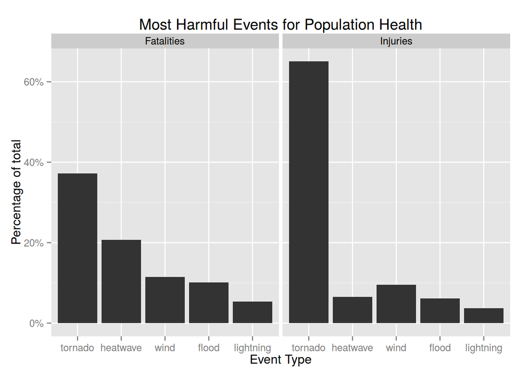

```r
temp <- head(databyev, 5)
temp <- select(temp, cleanevent, fatalitiespercent, injuriespercent)
temp$cleanevent <- as.factor(temp$cleanevent)
levels(temp$cleanevent)<- c("flood", "heatwave", "lightning",
                            "tornado", "wind")
temp$cleanevent <- reorder(temp$cleanevent, desc(temp$fatalitiespercent), min)
temp <- melt(temp, id.vars = "cleanevent", variable.name = "variable")
levels(temp$variable) <- c("Fatalities", "Injuries")
ggplot(temp, aes(x=cleanevent, y=value))+
  geom_bar(stat = "identity") +
  facet_grid( . ~ variable) +
  ggtitle("Most Harmful Events for Population Health")+
  xlab("Event Type") +
  ylab("Percentage of total")+
  scale_y_continuous(labels = percent)
```

### Effects on Economy

The five most harmful events account for more than 97% of the property damage and more than 84% of the crop damage. Those events are:

1. Floods
2. Hurricanes
3. Storms
4. Wind
5. Tornadoes

```r
head(databyeveco, 10)
```

```
##    cleanevent propertydamage   cropdamage propertydamagepercent
## 1       flood   1.285397e+14 5.007267e+12          4.657196e-01
## 2   hurricane   7.431036e+13 1.513995e+12          2.692381e-01
## 3       storm   5.291793e+13 5.000739e+12          1.917300e-01
## 4         win   8.016669e+12 2.201749e+09          2.904565e-02
## 5     tornado   5.351703e+12 4.149615e+08          1.939006e-02
## 6        fire   2.545957e+12 4.032816e+08          9.224401e-03
## 7        rain   2.500734e+12 8.061528e+08          9.060552e-03
## 8        hail   1.814177e+12 3.046887e+09          6.573049e-03
## 9       rough   1.046116e+09 1.512473e+12          3.790243e-06
## 10        sno   1.023255e+09 1.346631e+08          3.707413e-06
##    cropdamagepercent cumsumprop cumsumcrop
## 1       3.669539e-01  0.4657196  0.3669539
## 2       1.109520e-01  0.7349577  0.4779059
## 3       3.664755e-01  0.9266876  0.8443814
## 4       1.613535e-04  0.9557333  0.8445428
## 5       3.041015e-05  0.9751234  0.8445732
## 6       2.955420e-05  0.9843478  0.8446027
## 7       5.907831e-05  0.9934083  0.8446618
## 8       2.232889e-04  0.9999814  0.8448851
## 9       1.108404e-01  0.9999852  0.9557255
## 10      9.868686e-06  0.9999889  0.9557354
```

Plot a barplot:

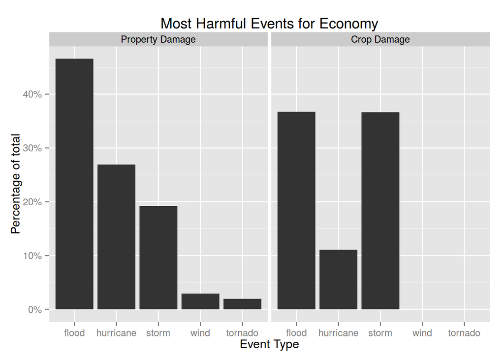

```r
temp <- head(databyeveco, 5)
temp <- select(temp, cleanevent, propertydamagepercent, cropdamagepercent)
temp$cleanevent <- as.factor(temp$cleanevent)
levels(temp$cleanevent)[5] <- "wind"
temp$cleanevent <- reorder(temp$cleanevent, desc(temp$propertydamagepercent), min)
temp <- melt(temp, id.vars = "cleanevent", variable.name = "variable")
levels(temp$variable) <- c("Property Damage", "Crop Damage")
ggplot(temp, aes(x=cleanevent, y=value))+
  geom_bar(stat = "identity") +
  facet_grid( . ~ variable) +
  ggtitle("Most Harmful Events for Economy")+
  xlab("Event Type") +
  ylab("Percentage of total")+
  scale_y_continuous(labels = percent)
```